# Problem Set 3

Topics in Econometrics

due May 27

# Exercise 1. K-means clustering

**(a)** Write the function `kmeans.objective` which takes as inputs

- `K`: the number of groups,
- `centers`: a $K \times p$ matrix which contains centers of $K$ groups in a $p$-dimensional space,
- `groups`: a $N \times 1$ vector which contains group memberships of $N$ observations,
- `X`: a $N \times p$ matrix which contains $N$ observations of $p$-dimensional vector,

and as the output

- the K-means objective function

$$\sum_{i=1}^N ||x_i - \overline x_{k_i}||^2$$
where $k_i$ is the group membership of $x_i$.

We assume the data are standardized and we use the standard Euclidean norm.

For norms that take account for the scales, see e.g. https://en.wikipedia.org/wiki/Mahalanobis_distance.

In the computational perspective, it is more efficient to standardize the data first as the output of interest is the group membership and the unstandardized centers are easily generated from the memberships.

```r
kmeans.objective = function(K, centers, groups, X) {

  # read dimensions
  N = nrow(X)
  p = ncol(X)

  ##### FILL IN THE REST #####

}
```

**(b)** Write the function `kmeans.updateCenters` which takes as inputs

- `K`: the number of groups,
- `groups`: a $N \times 1$ vector which contains group memberships of $N$ observations,
- `X`: a $N \times p$ matrix which contains $N$ observations of $p$-dimensional vector,

and the output

- a $K \times p$ matrix which contains centers of $K$ groups in a $p$-dimensional space.

Make sure to indicate an empty center when a group is empty.

```r
kmeans.updateCenters = function(K, groups, X) {

  # read dimensions
  N = nrow(X)
  p = ncol(X)

  ##### FILL IN THE REST #####

}
```

**(b)** Write the function `kmeans.updateGroups` which takes as inputs

- `K`: the number of groups,
- `centers`: a $K \times p$ matrix which contains centers of $K$ groups in a $p$-dimensional space,
- `X`: a $N \times p$ matrix which contains $N$ observations of $p$-dimensional vector,

and the output

- a $N \times 1$ vector which contains group memberships of $N$ observations.

```r
kmeans.updateGroups = function(K, centers, X) {

  # read dimensions
  N = nrow(X)
  p = ncol(X)

  ##### FILL IN THE REST #####

}
```

**(c)** Write the function `kmeans.estimateGroups` which takes as inputs

- `K`: the number of groups,
- `initCenters`: a $K \times p$ matrix which contains the initial centers of $K$ groups in a $p$-dimensional space,
- `X`: a $N \times p$ matrix which contains $N$ observations of $p$-dimensional vector,
- `tol`: the tolerance, with default `1e-06`,
- `maxiter`: maximum number of iterations, with default `1000`,

and the output

- a `List` which contains
  - `$groups`: a $N \times 1$ vector which contains the final group memberships of $N$ observations,
  - `$centers`: a $K \times p$ matrix which contains centers of the $K$ groups in a $p$-dimensional space,
  - `$objectives`: the sequence of kmeans objectives after each group update,
  - `$steps`: the sequence of the maximum changes of the center coordinates (see the left-hand side of the stopping criterion below),
  - `$status`: a string that explains which stopping criterion caused the algorithm to stop.

This implements the Lloyd’s algorithm. Note that

- we stop the algorithm when the updated center $c_k' = (c_{1k}', \ldots, c_{pk}')$ and the old center $c_k = (c_{1k}, \ldots, c_{pk})$ satisfies
  $$\max_k\{|c_{1k}' - c_{1k}|, \ldots, |c_{pk}' - c_{pk}|\} < \text{tol}.$$
  in which case we set `$status = "algorithm converged."`.
- we stop the algorithm when we obtain an empty group (hence the empty center), in which case we set `$status = "empty group appeared."` and terminate the algorithm.
- we stop the algorithm when we reach maximum number of iterations, in which case we set `$status = "max iteration reached."`

```r
kmeans.estimateGroups = function(K, initCenters, X, tol=1e-06, maxiter=1000) {

  # read dimensions
  N = nrow(X)
  p = ncol(X)

  ##### FILL IN THE REST #####

}
```

**(d)** Execute the following code and verify the results.

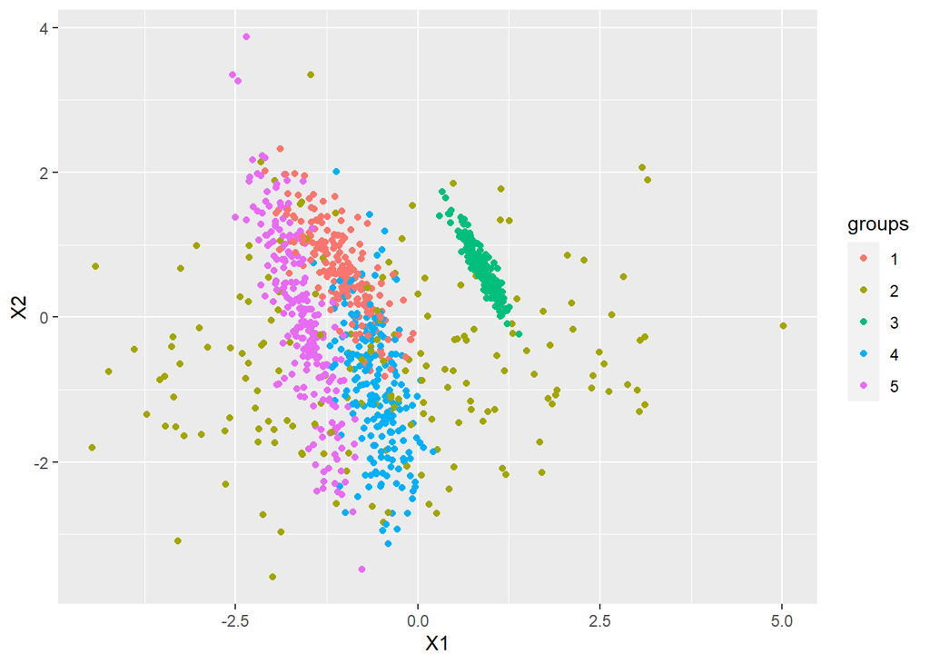

```r
# generate N observations of p-dimensional Gaussian mixture with K components with random means and variances
generateSample = function(N, p, K, meanScale=1, varScale=1) {

  # generate random mean vectors
  means = foreach(k=1:K) %do% { meanScale * rnorm(p) }
  # generate random variances
  vars = foreach(k=1:K) %do% {
    varChol = matrix(0, nrow=p, ncol=p)
    varChol[lower.tri(varChol, diag = TRUE)] = varScale * rnorm(p*(p+1)/2)
    varChol
  }

  # generate standard normal draws, into p * N matrix
  draws = matrix(rnorm(p*N), nrow=p, ncol=N)
  # generate group memberships
  groups = 1 + as.integer(runif(N, min=0, max=K))
  # location and scale shift according to the mixture components
  for(j in 1:K) {
    draws[,groups == j] = means[[j]] + vars[[j]] %*% draws[,groups == j]
  }
  # return draws and the true group membership
  return(list(draws=t(draws), centers=do.call(rbind, means), groups=groups))
}

# load library
library(foreach)
library(ggplot2)

# set seed
set.seed(400)

# specify model
model = list(N=1000, p=3, K=5, S=1000, meanScale=1, varScale=0.7)

# generate mixture model
data.mixture = generateSample(model$N, model$p, model$K, model$meanScale, model$varScale)

# visualize data using the first two coordinate
ggplot(data=data.frame(data.mixture$draws, groups=as.factor(data.mixture$groups))) + geom_point(aes(x=X1, y=X2, color=groups))
```

```r
########## estimate k-means with random initial values ##########

# initialize best choice
data.kmeans.minimum = list(objectives = Inf)
# try multiple initial points and pick the clustering with the minimum objective
for(s in 1:(model$S)) {
  est = kmeans.estimateGroups(K = model$K, initCenters = data.mixture$draws[sample.int(model$N, model$K),], X = data.mixture$draws)
  if(min(data.kmeans.minimum$objectives) > min(est$objectives)) {
    data.kmeans.minimum = est
  }
}

# print the best solution
data.kmeans.minimum
```

```
## $groups
##    [1] 3 2 5 1 5 4 3 1 3 2 4 5 2 2 3 1 2 4 3 1 1 3 3 5 2 3 4 1 1 3 4 4 1 2 3 1 1
##   [38] 4 4 1 1 1 4 1 5 1 1 2 3 1 4 5 2 1 2 1 1 5 2 4 2 4 1 3 5 4 4 4 4 2 2 2 2 4
##   [75] 1 3 1 1 2 4 3 2 1 5 2 3 3 4 3 1 2 3 4 1 4 1 2 3 1 1 1 2 3 2 4 1 1 2 3 2 1
##  [112] 3 4 1 2 2 1 2 2 1 1 2 4 4 2 4 4 1 4 2 2 4 2 4 2 4 3 4 2 5 4 2 3 3 1 2 2 4
##  [149] 1 2 2 4 2 4 1 4 5 2 2 1 4 5 3 2 4 2 5 2 1 4 1 4 4 2 2 3 4 4 1 3 1 3 1 3 2
##  [186] 1 1 3 1 1 1 4 4 1 2 3 2 4 1 1 4 4 5 1 4 3 2 3 2 4 5 1 3 2 3 3 2 4 1 3 2 3
##  [223] 2 1 1 1 2 1 2 2 1 1 1 3 2 1 4 1 5 2 1 3 4 1 4 3 1 3 4 3 4 2 2 1 2 1 2 4 4
##  [260] 1 1 3 4 1 3 3 1 1 3 2 2 3 4 2 4 4 4 1 4 1 1 5 1 2 1 1 2 5 3 3 1 2 2 1 3 1
##  [297] 3 4 3 1 4 2 5 2 4 1 4 4 4 2 1 1 4 2 3 2 1 5 4 4 3 1 4 2 2 4 2 1 2 4 3 4 1
##  [334] 4 1 1 2 3 1 1 2 1 4 4 3 3 1 1 5 2 1 4 5 1 1 3 1 2 1 1 2 5 4 3 3 1 3 1 2 3
##  [371] 4 1 2 2 5 5 1 4 2 3 3 2 4 1 1 4 4 3 3 4 3 1 1 1 1 1 2 3 2 4 1 4 2 2 2 1 1
##  [408] 3 4 1 3 1 4 4 2 5 5 5 1 2 1 5 1 1 1 2 4 4 4 2 5 4 3 4 4 2 1 4 1 1 4 4 4 1
##  [445] 4 1 4 4 3 1 4 2 4 4 3 2 2 1 2 1 2 3 5 3 2 2 1 3 1 3 1 5 1 3 1 3 1 3 1 1 1
##  [482] 3 1 5 1 2 2 4 1 4 2 2 5 2 5 2 1 4 4 2 2 2 1 1 2 2 4 1 1 1 3 3 3 4 2 2 3 1
```

[output cut: 34 more lines]

```r
# compare estimated centers and the true centers
list(estimated=data.kmeans.minimum$centers, true=data.mixture$centers)
```

```
## $estimated
##            [,1]       [,2]        [,3]
## [1,] -1.1419184  0.4983873  1.20882968
## [2,]  0.8472663  0.7141366  0.02739377
## [3,] -1.8509132  0.3026986 -1.36425041
## [4,] -0.7749889 -1.4842818 -0.72237670
## [5,]  1.3438749 -1.0195707 -2.82533444
##
## $true
##            [,1]        [,2]        [,3]
## [1,] -1.0365488  0.61528331  1.47293261
## [2,] -0.6826873 -0.60183857 -1.35260973
## [3,]  0.8607387  0.72037049  0.10785322
## [4,] -0.5745512 -0.90184718  0.08928709
## [5,] -1.5937957 -0.08685912 -1.17092161
```

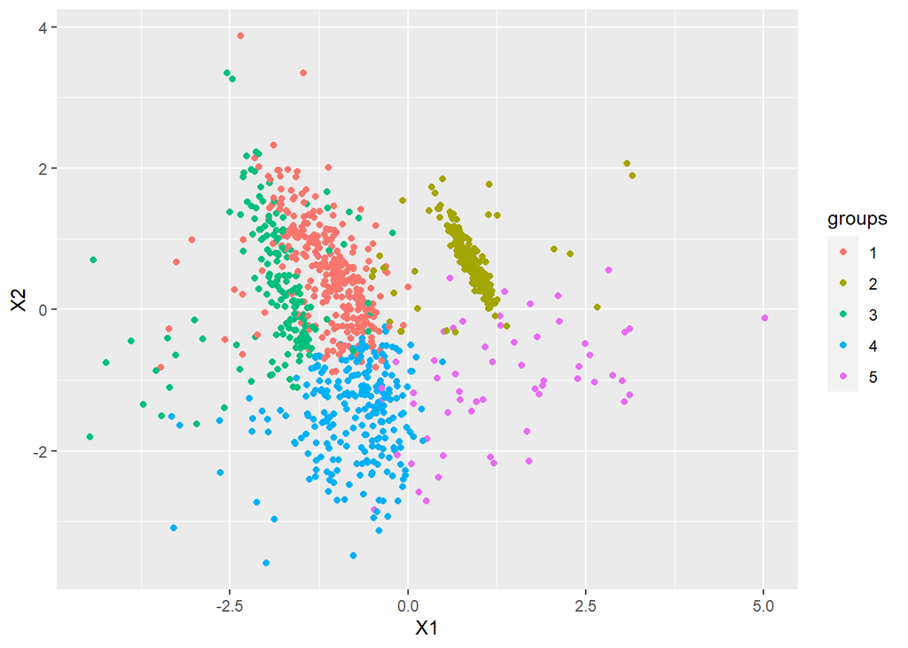

```r
# visualize data using the first two coordinate
ggplot(data=data.frame(data.mixture$draws, groups=as.factor(data.kmeans.minimum$groups))) + geom_point(aes(x=X1, y=X2, color=groups))
```

# Exercise 2. Trees

In this problem set, we only do some basic exercises about the trees. R is NOT the language to code up the trees efficiently. Here we try to understand how the trees are coded up in more efficient languages like C++.

Given the data points $(X_i, Y_i)_{i=1}^N$, we define a Tree Node in R as the `list` that has four elements:

- `$index`: a vector that contains the observation indices $\{1, \ldots, N\}$ which belongs to the Tree Node,
- `$y`: the mean of $Y_i$ for the $i$’s that belongs to the Tree Node,
- `$left`: another Tree Node that is a “left-leaf” of the current Tree Node,
- `$right`: another Tree Node that is a “right-leaf” of the current Tree Node.

A terminal Tree Node has `$left = NULL` and `$right = NULL`.

In this exercise, we consider the following simple dataset $(X_i, Y_i)_{i=1}^N$ with $N=100$ where $X_i \in \mathbb{R}$ and $Y_i \in \mathbb{R}$:

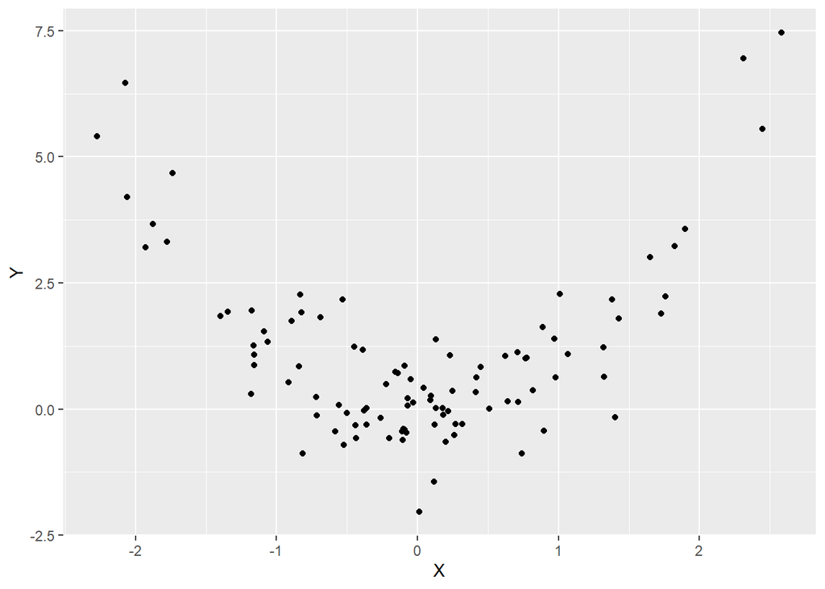

```r
set.seed(100)
data.X = rnorm(100)
data.Y = data.X^2 + rnorm(100)
data.simple = data.frame(X=data.X, Y=data.Y)
ggplot(data=data.simple) + geom_point(aes(x=X, y=Y))
```

To understand how we express the trees in R, we consider as an example the following classification tree for the first 4 observations of $(X_i, Y_i)$:

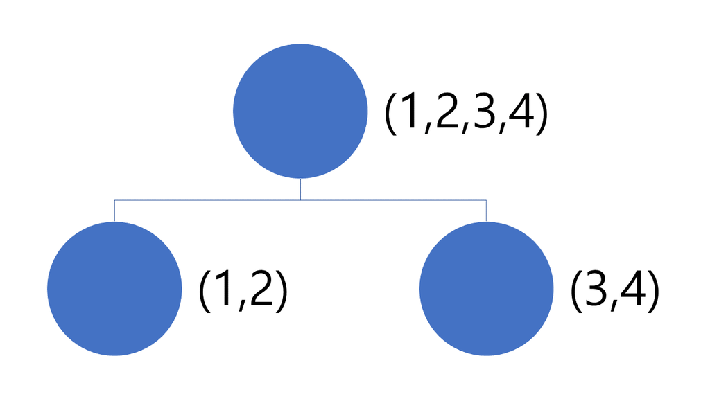

The following code expresses the above classification tree:

```r
list(

  index = c(1,2,3,4),

  y = mean(data.simple$Y[1:4]),

  left  = list(
    index = c(1,2),
    y     = mean(data.simple$Y[1:2]),
    left  = NULL,
    right = NULL
  ),

  right = list(
    index = c(3,4),
    y     = mean(data.simple$Y[3:4]),
    left  = NULL,
    right = NULL
  )

)
```

```
## $index
## [1] 1 2 3 4
##
## $y
## [1] 0.6165079
##
## $left
## $left$index
## [1] 1 2
##
## $left$y
## [1] 0.649844
##
## $left$left
## NULL
##
## $left$right
## NULL
##
##
## $right
## $right$index
## [1] 3 4
##
## $right$y
## [1] 0.5831717
##
## $right$left
## NULL
##
## $right$right
## NULL
```

**(a)** Write the function `tree.createTerminalNode` that takes as inputs

- `index`: a vector of observation indices that belongs to the terminal node,
- `data`: a `data.frame` that contains the one-dimensional variables `$X` and `$Y`,

and as the output

- a Tree Node representing a terminal node that contains `index`.

```r
tree.createTerminalNode = function(index, data) {

  ##### FILL IN THE REST #####

}
```

**(b)** Write the function `tree.addLeftNode` that takes as inputs

- `node`: a terminal Tree Node,
- `index`: a vector of observation indices that will belong to a left leaf of `node`,
- `data`: a `data.frame` that contains the one-dimensional variables `$X` and `$Y`,

and as the output

- a Tree Node whose `$left` entry is replaced with the terminal Tree Node that contains `index`.

Write also the function `tree.addRightNode` that performs the same operation as `tree.addLeftNode` except that it replaces the `$right` entry.

```r
tree.addLeftNode = function(node, index, data) {

  ##### FILL IN THE REST #####

}

tree.addRightNode = function(node, index, data) {

  ##### FILL IN THE REST #####

}
```

**(c)** Execute the code which creates the tree in the figure that follows. Verify the result.

```r
# create the root
data.tree.example = tree.createTerminalNode(c(1,2,3,4,5,6), data.simple)
# create the tier 1 leaves
data.tree.example = tree.addLeftNode (data.tree.example, c(1,2,3,4), data.simple)
data.tree.example = tree.addRightNode(data.tree.example, c(5,6), data.simple)
# create the tier 2 leaves
data.tree.example$left = tree.addLeftNode (data.tree.example$left, c(1,2), data.simple)
data.tree.example$left = tree.addRightNode(data.tree.example$left, c(3,4), data.simple)
# print the tree structure
print(data.tree.example)
```

```
## $index
## [1] 1 2 3 4 5 6
##
## $y
## [1] 0.1204899
##
## $left
## $left$index
## [1] 1 2 3 4
##
## $left$y
## [1] 0.6165079
##
## $left$left
## $left$left$index
## [1] 1 2
##
## $left$left$y
## [1] 0.649844
##
## $left$left$left
## NULL
##
## $left$left$right
## NULL
##
##
## $left$right
## $left$right$index
## [1] 3 4
##
## $left$right$y
## [1] 0.5831717
##
## $left$right$left
## NULL
##
## $left$right$right
## NULL
##
##
##
## $right
## $right$index
## [1] 5 6
##
## $right$y
## [1] -0.8715461
##
## $right$left
## NULL
##
## $right$right
## NULL
```

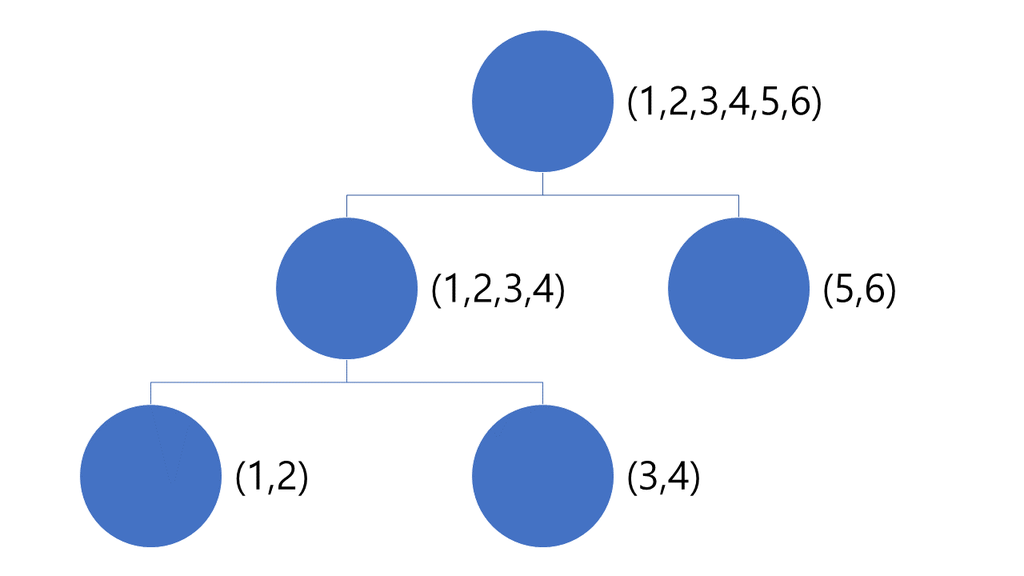

**(d)** Write the function `tree.grow` that takes as inputs

- `node`: a terminal Tree Node,
- `data`: a `data.frame` that contains the one-dimensional variables `$X` and `$Y`,

and as the output:

- If the terminal Tree Node is the node with only one observation index, return the terminal node itself;
- If not, return an updated Tree Node which partitions the indices in `node` into its left and right leaves, where the partition is the best rectangular partition of $X$ in the sense that it minimizes the MSE

$$\sum_{i ~\in~ \text{node}} (Y_i - \overline Y_{k(i)})^2$$

where $k(i) \in \{\text{"left"}, \text{"right"}\}$ represents whether the observation index $i$ belongs to the left or the right leaf and $\overline Y_{\text{"left"}}$ and $\overline Y_{\text{"right"}}$ are the means of the $Y$’s in the left and the right leaves, respectively.

Note that a rectangular partition in $X$ is the partition created according to the threshold rule, i.e.

$$\begin{aligned}
k(i) = \left\{\begin{array}{ll} \text{"left"} & \text{ if } X_i \leq c \\ \text{"right"} & \text{ if } X_i > c \end{array} \right.
\end{aligned}$$
for some $c \in \mathbb{R}$.

```r
tree.grow = function(node, data) {

  if(is.null(node) == TRUE | length(node$index) == 1) {

    return(node)

  } else {

    ##### FILL IN THE REST #####

  }

}
```

**(e)** Write the function `tree.predict` that takes as inputs

- `index`: the observation index,
- `tree`: the root Tree Node,

and as the output

- the value of `$y` (i.e. the mean of the $Y$’s) in the terminal Tree Node that the `index` belongs to.

Note that, to code up this function, a trick called “recursive function call” is very useful. See e.g. [this link](http://pages.cs.wisc.edu/~calvin/cs110/RECURSION.html) for an example. It uses C but the code is very simple so it should be readable. Note that `int X` in C means the variable X stores an integer and `void` means that the function has no return value.

```r
tree.predict = function(index, tree) {

  ##### FILL IN THE REST #####

}
```

**(f)** The following code grows three tiers of the leaves (hence having at most 8 terminal Tree Nodes) from the root Tree Node according to the best partition of $X$. Execute the code and verify the result.

```r
# create the root Tree Node
data.tree.optimal = tree.createTerminalNode(1:nrow(data.simple), data.simple)
# grow the tier 1 leaves
data.tree.optimal = tree.grow(data.tree.optimal, data.simple)
# grow the tier 2 leaves
data.tree.optimal$left  = tree.grow(data.tree.optimal$left,  data.simple)
data.tree.optimal$right = tree.grow(data.tree.optimal$right, data.simple)
# grow the tier 3 leaves
data.tree.optimal$left$left  = tree.grow(data.tree.optimal$left$left,  data.simple)
data.tree.optimal$left$right = tree.grow(data.tree.optimal$left$right, data.simple)
data.tree.optimal$right$left  = tree.grow(data.tree.optimal$right$left,  data.simple)
data.tree.optimal$right$right = tree.grow(data.tree.optimal$right$right, data.simple)

# load library
library(foreach)
library(ggplot2)

# attach the predicted Y values to the data frame
data.simple$Yhat = foreach(i=1:nrow(data.simple), .combine = "c") %do% {
  tree.predict(i, data.tree.optimal)
}

# print the number of clusters
length(unique(data.simple$Yhat))
```

```
## [1] 8
```

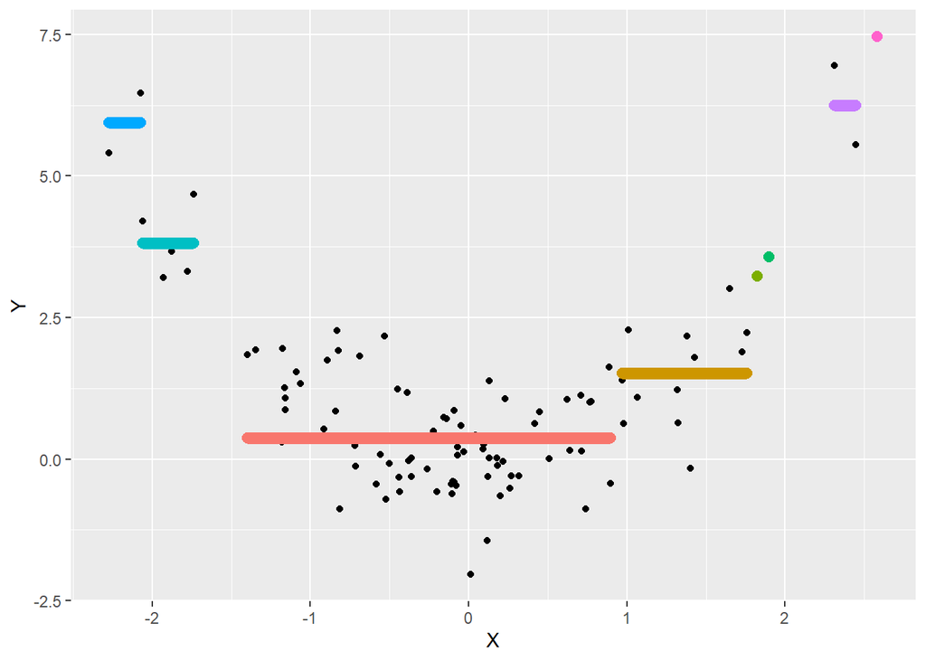

```r
# plot the result
ggplot(data=data.simple) + geom_point(aes(x=X, y=Y)) + geom_point(aes(x=X, y=Yhat, color=as.factor(Yhat)), size=2.5) + geom_line(aes(x=X, y=Yhat, color=as.factor(Yhat)), size=3) + theme(legend.position = "none")
```